# SHAP and Break Down for explaining prediction on the Titanic dataset

author: Witalis Domitrz witekdomitrz@gmail.com

I include the plots in static format to make it possible to read this as a static file.

## Preparation

### Install modules

```python
!pip install dalex
```

### Download the data

```python
!wget http://students.mimuw.edu.pl/~wd393711/iml/titanic.zip
!unzip -o titanic.zip
!rm titanic.zip
```

```
--2020-03-26 21:42:07--  http://students.mimuw.edu.pl/~wd393711/iml/titanic.zip
Resolving students.mimuw.edu.pl (students.mimuw.edu.pl)... 193.0.96.129, 2001:6a0:5001:1::3
Connecting to students.mimuw.edu.pl (students.mimuw.edu.pl)|193.0.96.129|:80... connected.
HTTP request sent, awaiting response... 200 OK
Length: 34877 (34K) [application/zip]
Saving to: ‘titanic.zip’

titanic.zip         100%[===================>]  34.06K  --.-KB/s    in 0.1s

2020-03-26 21:42:07 (285 KB/s) - ‘titanic.zip’ saved [34877/34877]

Archive:  titanic.zip
  inflating: gender_submission.csv
  inflating: test.csv
  inflating: train.csv
```

### Prepare the data

```python
import numpy as np
import pandas as pd

used_columns = ['Pclass', 'Sex', 'Age', 'SibSp', 'Parch', 'Fare', 'Embarked', 'Survived']
X_columns = ['Pclass', 'Age', 'SibSp', 'Parch', 'Fare', 'Sex_male', 'Embarked_C', 'Embarked_Q', 'Embarked_S']
Y_columns = ['Survived']

def load_data(fn):
    return pd.read_csv(fn).set_index('PassengerId')

def to_array(data):
    return pd.get_dummies(data).astype(dtype='float32')

def data_preprocessing():
    global train, test
    train = load_data('./train.csv')
    test = load_data('./gender_submission.csv').join(load_data('./test.csv'))

    train['is_train'] = True
    test['is_train'] = False
    data = pd.concat([train, test])

    # Replace missing values with mean
    data.fillna(data.mean(), inplace=True)

    # Split test and train
    train, test = data[data['is_train']], data[data['is_train'] == False]

    # No unused columns
    train, test = train[used_columns], test[used_columns]

    train, test = to_array(train), to_array(test)
data_preprocessing()


def split_to_x_y(data):
    return to_array(data[X_columns]), to_array(data[Y_columns])

def get_data():
    return split_to_x_y(train), split_to_x_y(test)

def unlabel_data(*sets):
    return ((part.values for part in subset) for subset in sets)
```

```python
(train_x, train_y), (test_x, test_y) = get_data()
```

## 1.

For the selected data set, train at least one tree-based ensemble model (random forest, gbm, catboost or any other boosting)

```python
from xgboost import XGBClassifier as Model
```

### Create a model

```python
model = Model(max_depth=4)
```

### Train a model

```python
model.fit(train_x, train_y)
```

```
XGBClassifier(base_score=0.5, booster='gbtree', colsample_bylevel=1,
              colsample_bynode=1, colsample_bytree=1, gamma=0,
              learning_rate=0.1, max_delta_step=0, max_depth=4,
              min_child_weight=1, missing=None, n_estimators=100, n_jobs=1,
              nthread=None, objective='binary:logistic', random_state=0,
              reg_alpha=0, reg_lambda=1, scale_pos_weight=1, seed=None,
              silent=None, subsample=1, verbosity=1)
```

### Check the first model accuracy

```python
from sklearn.metrics import accuracy_score
test_pred = model.predict(test_x)
test_accuracy1 = accuracy_score(test_y, [round(value) for value in test_pred])
print("Test accuracy of the first model: {}".format(test_accuracy1))
```

```
Test accuracy of the first model: 0.8827751196172249
```

## 2.

for some selected observation from this dataset, calculate the model predictions for model (1)

### Select an observation

```python
test.loc[[896]]
```

| PassengerId | Pclass | Age | SibSp | Parch | Fare | Survived | Sex_female | Sex_male | Embarked_C | Embarked_Q | Embarked_S |
| --- | --- | --- | --- | --- | --- | --- | --- | --- | --- | --- | --- |
| 896 | 3.0 | 22.0 | 1.0 | 1.0 | 12.2875 | 1.0 | 1.0 | 0.0 | 0.0 | 0.0 | 1.0 |

```python
def select_an_observation(id):
    obs = test.loc[[id]]
    x, y = split_to_x_y(obs)
    return (x, y), obs
```

```python
(x2, y2), obs2 = select_an_observation(894)
```

```python
obs2
```

| PassengerId | Pclass | Age | SibSp | Parch | Fare | Survived | Sex_female | Sex_male | Embarked_C | Embarked_Q | Embarked_S |
| --- | --- | --- | --- | --- | --- | --- | --- | --- | --- | --- | --- |
| 894 | 2.0 | 62.0 | 0.0 | 0.0 | 9.6875 | 0.0 | 0.0 | 1.0 | 0.0 | 1.0 | 0.0 |

### Calculate the model predictions

```python
pred2 = model.predict(x2)
print("The model preadictet that this person would survive:", pred2[0], "and the truth is:", y2.values[0,0])
```

```
The model preadictet that this person would survive: 0.0 and the truth is: 0.0
```

## 3.

for an observation selected in (2), calculate the decomposition of model prediction using SHAP, Break Down or both (packages for R: DALEX, iml, packages for python: shap, dalex, piBreakDown).

### Use dalex

```python
from dalex.explainer import Explainer
```

### Create an explainer

```python
explainer = Explainer(model=model, data=test_x, y=test_y['Survived'], model_type='classifier')
```

```
Preparation of a new explainer is initiated

  -> label             : not specified, model's class taken instead!
  -> data              : 418 rows 9 cols
  -> target variable   :  Argument 'y' was a pandas.Series. Converted to a numpy.ndarray.
  -> target variable   : 418 values
  -> predict function  : <function yhat.<locals>.<lambda> at 0x7ff717ad0c80> will be used
  -> predicted values  : min = 0.02384374, mean = 0.39167467, max = 0.9952514
  -> residual function : difference between y and yhat
  -> residuals         : min = -0.9741459, mean = -0.028038295, max = 0.94087017
  -> model_info        : package xgboost

A new explainer has been created!
```

### Create an explainer function using Break Down (and optionally Shap)

```python
def explain(x, explainer=explainer, use_shap=False):
    # Shap
    if use_shap:
        shap = explainer.predict_parts(x, type='shap')
        shap.plot()

    # Break Down
    break_down = explainer.predict_parts(x, type='break_down')
    break_down.plot()
```

### Explain using Shap and Break Down

```python
x3 = x2
explain(x3, use_shap=True)
```

[interactive chart not shown]

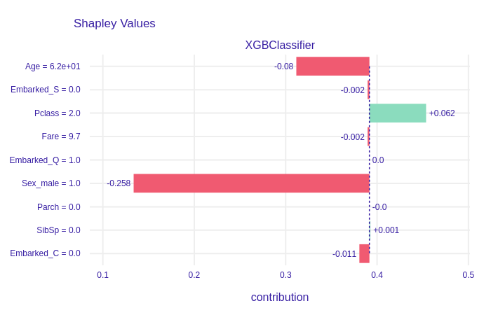

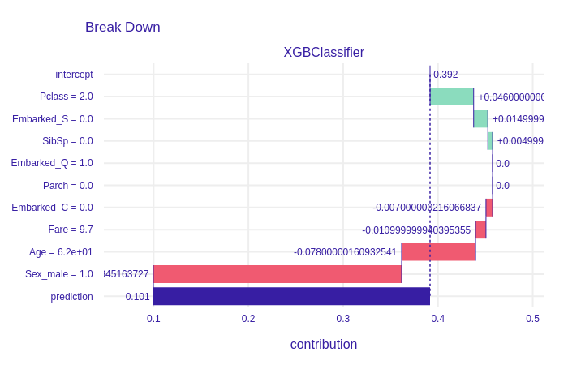

From this point on I will focus on Break Down.

## 4.

find two observations in the data set, such that they have different most important variables (e.g. age and gender are the most important for observation A, but race and class for observation B)

```python
((x4A, _), _), ((x4B, _), _) = select_an_observation(1066), select_an_observation(1296)
explain(x4A)
explain(x4B)
```

[interactive chart not shown]

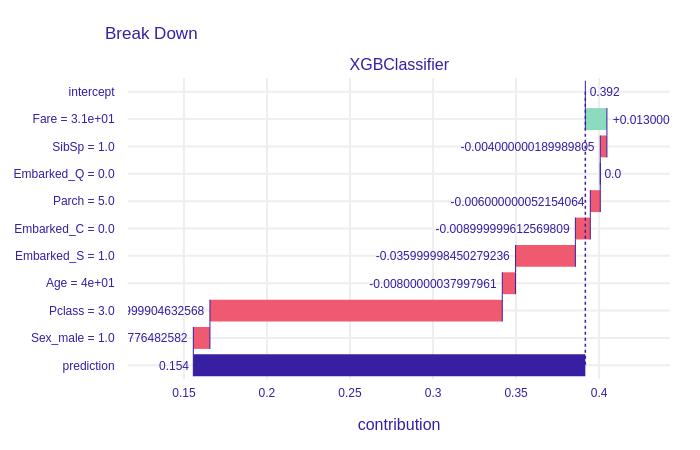

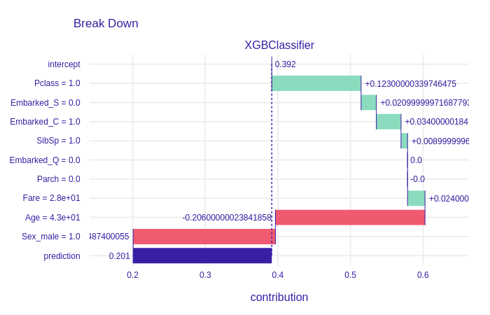

## 5.

select one variable and find two observations in the data set such that for one observation this variable has a positive effect and for the other a negative effect

```python
test[test['Age'] < 30]
```

| PassengerId | Pclass | Age | SibSp | Parch | Fare | Survived | Sex_female | Sex_male | Embarked_C | Embarked_Q | Embarked_S |
| --- | --- | --- | --- | --- | --- | --- | --- | --- | --- | --- | --- |
| 895 | 3.0 | 27.000000 | 0.0 | 0.0 | 8.662500 | 0.0 | 0.0 | 1.0 | 0.0 | 0.0 | 1.0 |
| 896 | 3.0 | 22.000000 | 1.0 | 1.0 | 12.287500 | 1.0 | 1.0 | 0.0 | 0.0 | 0.0 | 1.0 |
| 897 | 3.0 | 14.000000 | 0.0 | 0.0 | 9.225000 | 0.0 | 0.0 | 1.0 | 0.0 | 0.0 | 1.0 |
| 899 | 2.0 | 26.000000 | 1.0 | 1.0 | 29.000000 | 0.0 | 0.0 | 1.0 | 0.0 | 0.0 | 1.0 |
| 900 | 3.0 | 18.000000 | 0.0 | 0.0 | 7.229200 | 1.0 | 1.0 | 0.0 | 1.0 | 0.0 | 0.0 |
| ... | ... | ... | ... | ... | ... | ... | ... | ... | ... | ... | ... |
| 1302 | 3.0 | 29.881138 | 0.0 | 0.0 | 7.750000 | 1.0 | 1.0 | 0.0 | 0.0 | 1.0 | 0.0 |
| 1304 | 3.0 | 28.000000 | 0.0 | 0.0 | 7.775000 | 1.0 | 1.0 | 0.0 | 0.0 | 0.0 | 1.0 |
| 1305 | 3.0 | 29.881138 | 0.0 | 0.0 | 8.050000 | 0.0 | 0.0 | 1.0 | 0.0 | 0.0 | 1.0 |
| 1308 | 3.0 | 29.881138 | 0.0 | 0.0 | 8.050000 | 0.0 | 0.0 | 1.0 | 0.0 | 0.0 | 1.0 |
| 1309 | 3.0 | 29.881138 | 1.0 | 1.0 | 22.358299 | 0.0 | 0.0 | 1.0 | 1.0 | 0.0 | 0.0 |

271 rows × 11 columns

```python
((x5A, _), _), ((x5B, _), _) = select_an_observation(1305), select_an_observation(1304)
explain(x5A)
explain(x5B)
```

[interactive chart not shown]

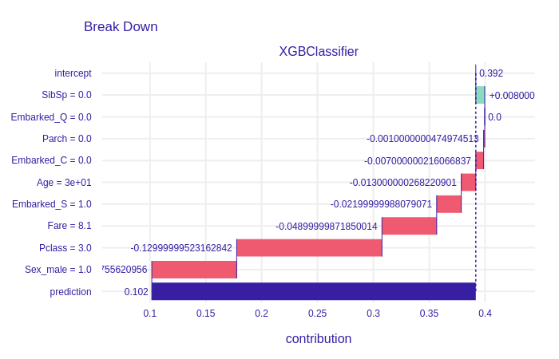

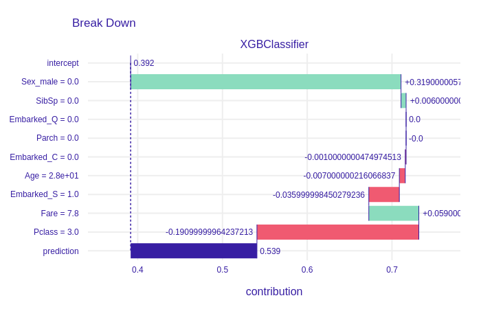

## 6.

train a second model (of any class, neural nets, linear, other boosting) and find an observation for which BD/shap attributions are different between the models

```python
from sklearn.ensemble import RandomForestClassifier as Model2
```

### Create a model

```python
model2 = Model2()
```

### Train a model

```python
model2.fit(train_x, train_y)
```

```
RandomForestClassifier(bootstrap=True, ccp_alpha=0.0, class_weight=None,
                       criterion='gini', max_depth=None, max_features='auto',
                       max_leaf_nodes=None, max_samples=None,
                       min_impurity_decrease=0.0, min_impurity_split=None,
                       min_samples_leaf=1, min_samples_split=2,
                       min_weight_fraction_leaf=0.0, n_estimators=100,
                       n_jobs=None, oob_score=False, random_state=None,
                       verbose=0, warm_start=False)
```

### Check the second model accuracy

```python
from sklearn.metrics import accuracy_score
test_pred = model2.predict(test_x)
test_accuracy1 = accuracy_score(test_y, [round(value) for value in test_pred])
print("Test accuracy of the second model: {}".format(test_accuracy1))
```

```
Test accuracy of the second model: 0.8181818181818182
```

```python
explainer2 = Explainer(model=model2, data=test_x, y=test_y['Survived'], model_type='classifier')
```

```
Preparation of a new explainer is initiated

  -> label             : not specified, model's class taken instead!
  -> data              : 418 rows 9 cols
  -> target variable   :  Argument 'y' was a pandas.Series. Converted to a numpy.ndarray.
  -> target variable   : 418 values
  -> predict function  : <function yhat.<locals>.<lambda> at 0x7ff72c9a9378> will be used
  -> predicted values  : min = 0.0, mean = 0.3966628952559153, max = 1.0
  -> residual function : difference between y and yhat
  -> residuals         : min = -0.99, mean = -0.0330265316195516, max = 0.98
  -> model_info        : package sklearn

A new explainer has been created!
```

### Find an observation for which BD attributions are different between the models

```python
((x6, _), _) = select_an_observation(1234)
explain(x6, explainer)
explain(x6, explainer2)
```

[interactive chart not shown]

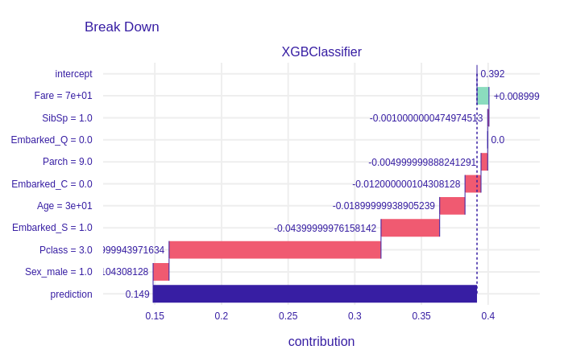

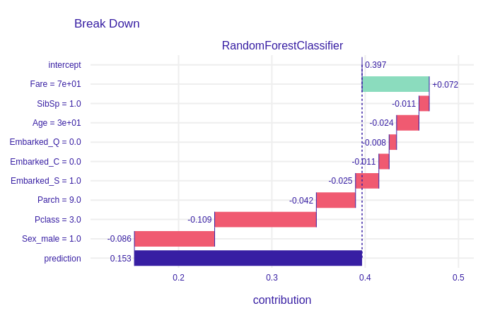

## 7.

Comment on the results for points (4), (5) and (6)

1. Different most important variables

   We can clearly see that the most important variable for the first person is the class, which clearly dominates all the others. It is not the case for the second person, for whom the class is also important, but the age and being the male contributes in that case much more. It is even more interesting in the sex variable, because overall it is the most influential variable in the whole dataset. In the case of the first person, which is of the same sex as the second one, it is dominated by the class and almost insignificant. By analyzing the dataset we can further conclude that the class is not so significant for the second person, because being in the first class did not guarantee survival, while being in the middle-aged male in the third class was almost a certain death.
2. Positive and negative effect of one variable

   The chosen example presents well that similar fare (8.1 and 7.8) may have diametralny different effect in two distinct cases. In the first one it is the third biggest negative factor whereas in the second one it is the second most influential positive variable. It is not clear for me why the is such a strange correlation and it might be a defect of this model.
3. Differences between two models

   Two compared models, while predicting almost the same result (0.149 and 0.153) drastically differ in handling different informations. In the first model we see much higher focus on one variable whereas in the second one it is more distributed. Moreover in the second model very high fare, being the first factor taken in the consideration affects the resulting value almost 9 times more than in the first model. It is also interesting that the last considered variable - the sex of the person, is so influential in the second model, while being almost negligible in the first one.